# Bollywood Data Analysis

### Please refer scope of work file of this project before starting to view this analysis

In India, Bollywood is a leading film industry. Many movies are released; some have small budgets, and some have big budgets. I was wondering that movies with higher budgets are liked by people or not. To solve this question, I am conducting this data analysis. Along with this task we might find some other interesting things.

#### Loading required libraries

```r
library(tidyverse)
(.packages())
```

```
##  [1] "forcats"   "stringr"   "dplyr"     "purrr"     "readr"     "tidyr"
##  [7] "tibble"    "ggplot2"   "tidyverse" "stats"     "graphics"  "grDevices"
## [13] "utils"     "datasets"  "methods"   "base"
```

#### Loading data set

```r
bollywood_df <- read.csv("bollywood_dataset.csv")
bollywood_df <- head(bollywood_df, - 2)
view(bollywood_df)
str(bollywood_df)
```

```
## 'data.frame':    684 obs. of  12 variables:
##  $ Film                                    : chr  "Baby" "Dolly Ki Doli" "Rahasya" "Khamoshiyan" ...
##  $ Released_Year                           : int  2015 2015 2015 2015 2015 2015 2015 2015 2015 2015 ...
##  $ Released_month                          : chr  "January" "January" "January" "January" ...
##  $ Director                                : chr  "Neeraj Pandey" "Abhishek Dogra" "Manish Gupta" "Karan Darra" ...
##  $ Cast_1                                  : chr  "Akshay Kumar" "\tSonam Kapoor" "Kay Kay Menon" "\tGurmeet Choudhary" ...
##  $ Cast_2                                  : chr  "Danny Denzongpa" "Pulkit Samrat" "Ashish Vidyarthi" "Ali Fazal" ...
##  $ Genre_1                                 : chr  "Action" "Comedy" "Social" "Drama" ...
##  $ Genre_2                                 : chr  "Thriller" "" "" "" ...
##  $ IMDB_Ratings                            : num  8 4.5 7.6 4 5 3.7 4.2 5.5 7.4 2.8 ...
##  $ IMDB_Users                              : int  56882 3052 4856 1315 287 1721 3170 1917 23601 197 ...
##  $ Budget_in_crore.INR.                    : chr  "58.97" "21.00" "6.00" "10.00" ...
##  $ Worldwide_box_office_gross_in_crore.INR.: chr  "142.99" "19.21" "2.80" "14.00" ...
```

```r
head(bollywood_df)
```

|  | Film | Released_Year | Released_month | Director | Cast_1 | Cast_2 | Genre_1 | Genre_2 | IMDB_Ratings | IMDB_Users | Budget_in_crore.INR. | Worldwide_box_office_gross_in_crore.INR. |
| --- | --- | --- | --- | --- | --- | --- | --- | --- | --- | --- | --- | --- |
| 1 | Baby | 2015 | January | Neeraj Pandey | Akshay Kumar | Danny Denzongpa | Action | Thriller | 8.0 | 56882 | 58.97 | 142.99 |
| 2 | Dolly Ki Doli | 2015 | January | Abhishek Dogra | \tSonam Kapoor | Pulkit Samrat | Comedy |  | 4.5 | 3052 | 21.00 | 19.21 |
| 3 | Rahasya | 2015 | January | Manish Gupta | Kay Kay Menon | Ashish Vidyarthi | Social |  | 7.6 | 4856 | 6.00 | 2.80 |
| 4 | Khamoshiyan | 2015 | January | Karan Darra | \tGurmeet Choudhary | Ali Fazal | Drama |  | 4.0 | 1315 | 10.00 | 14.00 |
| 5 | Sharafat Gayi Tel Lene | 2015 | January | Gurmmeet Singh | Zayed Khan | Tena Desae | Comedy |  | 5.0 | 287 | 7.00 | 0.57 |
| 6 | Alone | 2015 | January | Bhusan Patel | Bipasha Basu | Karan Singh Grover | Horror | Romance | 3.7 | 1721 | 19.00 | 25.85 |

# Start of the analysis

### How many movies were released from 1/01/2015 to 31/12/2021 ?

```r
summarise(bollywood_df, Total = n())
```

| Total |
| --- |
| 684 |

### There were 684 movies released in theater and on OTT platforms from 1-01-2015 to 31-12-2021.

### Which year produced lowest number of films and highest number films ? What is the average production of the movies per year ?

```r
movies_produced_yearly <- bollywood_df %>% group_by(Released_Year) %>%
                                        summarise(Total_movies = n())
movies_produced_yearly
```

| Released_Year | Total_movies |
| --- | --- |
| 2015 | 71 |
| 2016 | 105 |
| 2017 | 114 |
| 2018 | 127 |
| 2019 | 127 |
| 2020 | 66 |
| 2021 | 74 |

```r
round(mean(movies_produced_yearly$Total_movies))
```

```
## [1] 98
```

### Lowest production year was 2020 with a total of 66 movies, and Highest production year was 2018 and 2019, both years producing a total of 127 movies with an average production of movies per year is 98.

### Does the production of movies increase or decrease year by year ? Is there any trend and can we find out why ?

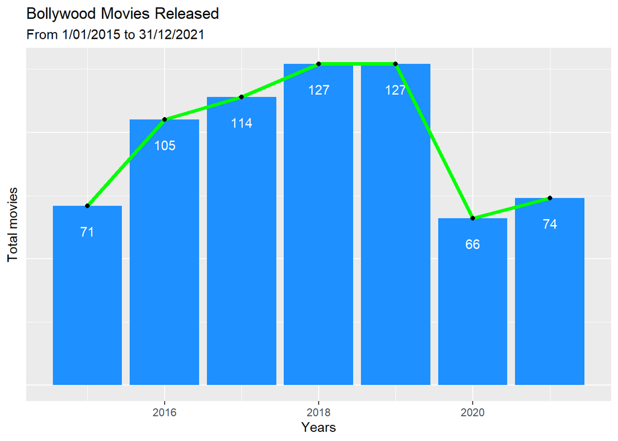

```r
graph_1 <- movies_produced_yearly %>%
  ggplot(aes(x=Released_Year, y=Total_movies)) +
  geom_col(fill = "#1E90FF") +
  labs(x="Years", y="Total movies", title = "Bollywood Movies Released", subtitle = "From 1/01/2015 to 31/12/2021") +
  geom_text(aes(label = Total_movies), vjust = 3 ,  col = "White") +
  theme(axis.text.y=element_blank(), axis.ticks.y=element_blank()) +
  geom_line(color="green",size=1.5) +
  geom_point()

graph_1
```

### As we can see from the graph, the production of the movies increased year by year till 2019 as 2018 and 2019 both produced the same amount of movies and then production of the movies suddenly dropped in 2020. The reason was due to pandemic and strict lockdown was followed in India due to this all production was closed and many movies were released directly on OTT platforms, which is why some movies never revealed the budget and earnings. But there is a rise in 2021.

### What are the average movie ratings of all movies released in this period ? Which year produced low quality content and high quality content according to ratings ?

```r
mean(bollywood_df$IMDB_Ratings)
```

```
## [1] 5.842251
```

```r
yearly_average_ratings <- bollywood_df %>% group_by(Released_Year) %>%
                                        summarise(mean_ratings = mean(IMDB_Ratings))

yearly_average_ratings
```

| Released_Year | mean_ratings |
| --- | --- |
| 2015 | 5.685915 |
| 2016 | 5.737143 |
| 2017 | 5.715789 |
| 2018 | 5.923622 |
| 2019 | 5.826772 |
| 2020 | 5.816667 |
| 2021 | 6.245946 |

### The average movie ratings are 5.84 in this period. The lowest average ratings are 5.69 which was in the year 2015, and the highest average ratings are 6.25 which was in the year 2021.

### Does the quality of movies increasing or decreasing year by year ? Is there any trend we can find ?

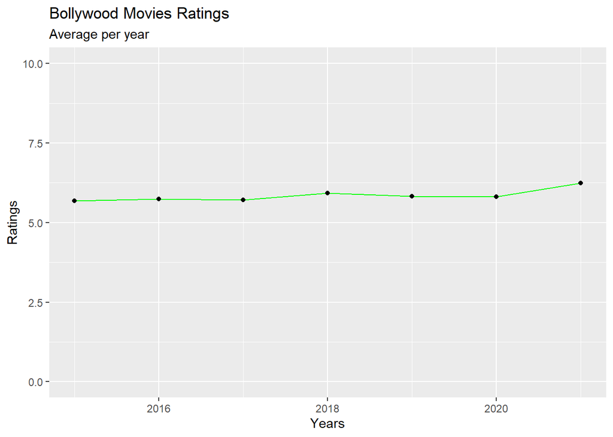

```r
graph_2 <- yearly_average_ratings %>%
  ggplot(aes(x=Released_Year, y=mean_ratings)) +
  labs(x="Years", y="Ratings", title = "Bollywood Movies Ratings", subtitle = "Average per year") +
  geom_line(color="green",size=0.5) +
  geom_point() +
  ylim(0,10)

graph_2
```

### We can say that the content quality of the movies increased not that much. But it is positive as compared to 2015, so we can say that people are liking what Bollywood is delivering throughout those years.

### Which are the top 100 movies according to ratings?

#### Here I have filtered out those movies which have user counts of less than 500 to avoid bias because some movies have higer ratings with less number of users backing it

```r
top_100_ratings <- bollywood_df %>%
  filter(IMDB_Users >= 500)

top_100_ratings <- top_100_ratings[order(top_100_ratings$IMDB_Ratings, decreasing = TRUE),]
top_100_ratings <- head(top_100_ratings, 100)
top_100_ratings
```

|  | Film | Released_Year | Released_month | Director | Cast_1 | Cast_2 | Genre_1 | Genre_2 | IMDB_Ratings | IMDB_Users | Budget_in_crore.INR. | Worldwide_box_office_gross_in_crore.INR. |
| --- | --- | --- | --- | --- | --- | --- | --- | --- | --- | --- | --- | --- |
| 478 | Code Name Abdul | 2021 | December | Eshwar Gunturu | Tanisha Mukherjee | Khatera Hakimi | Drama |  | 8.9 | 591 | null | null |
| 336 | Little Baby | 2019 | September | Shekhar S Jha | Priyanshu Chatterje | Gulnaz Siganporia | Drama |  | 8.7 | 6612 | null | 0.01 |
| 452 | Shershaah | 2021 | August | Vishnu Vardhan | Sidharth Malhotra | Kiara Advani | Biography | Drama | 8.7 | 116479 | 55.00 | 136.00 |
| 462 | Sardar Udham | 2021 | October | Shoojit Sircar | Vicky Kaushal | Banita Sandhu | Drama | Thriller | 8.7 | 38920 | 30.00 | null |
| 471 | Ye Mard Bechara | 2021 | November | Anuup Thapa | Manukriti Pahwa | Seema Pahwa | Drama |  | 8.7 | 1070 | 10.00 | 0.05 |
| 153 | Sachin A Billion Dreams | 2017 | May | James Erskine | Sachin Tendulkar | Arjun Tendulkar | Biography |  | 8.6 | 8022 | 39.00 | 64.95 |
| 327 | Family Of Thakurganj | 2019 | July | Manoj K Jha | Jimmy Sheirgill | Mahie Gill | Action | Comedy | 8.6 | 1630 | 15.00 | 0.49 |
| 129 | Dangal | 2016 | December | Nitesh Tiwari | Aamir Khan | Sakshi Tanwar | Biography |  | 8.4 | 181817 | 132.00 | 702.48 |
| 81 | Nil Battey Sannata | 2016 | April | Ashwiny Iyer Tiwari | Swara Bhaskar | Ratna Pathak | Drama |  | 8.3 | 6749 | 8.00 | 6.00 |
| 31 | Drishyam | 2015 | July | Nishikant Kamat | Ajay Devgn | Tabu | Thriller |  | 8.2 | 79403 | 62.00 | 110.43 |

[output cut: 90 more lines]

```r
head(top_100_ratings,1)
```

|  | Film | Released_Year | Released_month | Director | Cast_1 | Cast_2 | Genre_1 | Genre_2 | IMDB_Ratings | IMDB_Users | Budget_in_crore.INR. | Worldwide_box_office_gross_in_crore.INR. |
| --- | --- | --- | --- | --- | --- | --- | --- | --- | --- | --- | --- | --- |
| 478 | Code Name Abdul | 2021 | December | Eshwar Gunturu | Tanisha Mukherjee | Khatera Hakimi | Drama |  | 8.9 | 591 | null | null |

### According to this ratings, the top rank goes to Code Name Abdul movie with imdb ratings of 8.9.

### Which are the top 100 movies according to budget?

```r
top_100_budget <- subset(bollywood_df, bollywood_df$Budget_in_crore.INR. != "null")
str(top_100_budget)
```

```
## 'data.frame':    496 obs. of  12 variables:
##  $ Film                                    : chr  "Baby" "Dolly Ki Doli" "Rahasya" "Khamoshiyan" ...
##  $ Released_Year                           : int  2015 2015 2015 2015 2015 2015 2015 2015 2015 2015 ...
##  $ Released_month                          : chr  "January" "January" "January" "January" ...
##  $ Director                                : chr  "Neeraj Pandey" "Abhishek Dogra" "Manish Gupta" "Karan Darra" ...
##  $ Cast_1                                  : chr  "Akshay Kumar" "\tSonam Kapoor" "Kay Kay Menon" "\tGurmeet Choudhary" ...
##  $ Cast_2                                  : chr  "Danny Denzongpa" "Pulkit Samrat" "Ashish Vidyarthi" "Ali Fazal" ...
##  $ Genre_1                                 : chr  "Action" "Comedy" "Social" "Drama" ...
##  $ Genre_2                                 : chr  "Thriller" "" "" "" ...
##  $ IMDB_Ratings                            : num  8 4.5 7.6 4 5 3.7 4.2 5.5 7.4 2.8 ...
##  $ IMDB_Users                              : int  56882 3052 4856 1315 287 1721 3170 1917 23601 197 ...
##  $ Budget_in_crore.INR.                    : chr  "58.97" "21.00" "6.00" "10.00" ...
##  $ Worldwide_box_office_gross_in_crore.INR.: chr  "142.99" "19.21" "2.80" "14.00" ...
```

#### Here I needed to chage the datatype of budget column to numeric because it was in character

```r
top_100_budget$Budget_in_crore.INR. <- as.numeric(top_100_budget$Budget_in_crore.INR.)
top_100_budget <- top_100_budget[order(top_100_budget$Budget_in_crore.INR., decreasing = TRUE),]
top_100_budget <- head(top_100_budget, 100)
top_100_budget
```

|  | Film | Released_Year | Released_month | Director | Cast_1 | Cast_2 | Genre_1 | Genre_2 | IMDB_Ratings | IMDB_Users | Budget_in_crore.INR. | Worldwide_box_office_gross_in_crore.INR. |
| --- | --- | --- | --- | --- | --- | --- | --- | --- | --- | --- | --- | --- |
| 409 | Thugs Of Hindostan | 2018 | November | Vijay Krishna Acharya | Amitabh Bachchan | Aamir Khan | Action | Thriller | 4.0 | 19352 | 310.00 | 245.09 |
| 415 | Zero | 2018 | December | Anand L Rai | Shahrukh Khan | Anushka Sharma | Action | Comedy | 5.2 | 27174 | 270.00 | 191.44 |
| 676 | 83 (2021) | 2021 | December | Kabir Khan | Ranveer Singh | Jeeva | Biography | Drama | 7.7 | 31683 | 260.00 | 186.97 |
| 674 | Sooryavanshi | 2021 | November | Rohit Shetty | Akshay Kumar | Katrina Kaif | Action | Thriller | 6.9 | 74999 | 250.00 | 298.84 |
| 485 | Bharat | 2019 | June | Ali Abbas Zafar | Salman Khan | Katrina Kaif | Action | Adventure | 4.7 | 30606 | 240.00 | 308.70 |
| 291 | Padmaavat | 2018 | January | Sanjay Leela Bhansali | Deepika Padukone | Ranveer Singh | Drama |  | 7.0 | 31272 | 215.00 | 545.93 |
| 278 | Tiger Zinda Hai | 2017 | December | Ali Abbas Zafar | Salman Khan | Katrina Kaif | Action |  | 5.9 | 28510 | 210.00 | 565.10 |
| 524 | War | 2019 | October | Siddharth Anand | Hrithik Roshan | Tiger Shroff | Action | Drama | 6.5 | 23816 | 205.00 | 442.42 |
| 344 | Race 3 | 2018 | June | Remo DSouza | Salman Khan | Jacqueline Fernandez | Action | Thriller | 1.9 | 45962 | 185.00 | 305.16 |
| 65 | Prem Ratan Dhan Payo | 2015 | November | Sooraj Barjatya | Salman Khan | Sonam Kapoor | Drama |  | 4.5 | 21791 | 180.00 | 365.45 |

[output cut: 90 more lines]

```r
head(top_100_budget,1)
```

|  | Film | Released_Year | Released_month | Director | Cast_1 | Cast_2 | Genre_1 | Genre_2 | IMDB_Ratings | IMDB_Users | Budget_in_crore.INR. | Worldwide_box_office_gross_in_crore.INR. |
| --- | --- | --- | --- | --- | --- | --- | --- | --- | --- | --- | --- | --- |
| 409 | Thugs Of Hindostan | 2018 | November | Vijay Krishna Acharya | Amitabh Bachchan | Aamir Khan | Action | Thriller | 4 | 19352 | 310 | 245.09 |

### The most expensive movie was Thugs of Hindustan with the budget of 310 crores, which was released in 2018.

### Which are the top 100 movies according to box office ?

```r
top_100_box_office <- subset(bollywood_df, bollywood_df$Worldwide_box_office_gross_in_crore.INR. != "null")
str(top_100_box_office)
```

```
## 'data.frame':    501 obs. of  12 variables:
##  $ Film                                    : chr  "Baby" "Dolly Ki Doli" "Rahasya" "Khamoshiyan" ...
##  $ Released_Year                           : int  2015 2015 2015 2015 2015 2015 2015 2015 2015 2015 ...
##  $ Released_month                          : chr  "January" "January" "January" "January" ...
##  $ Director                                : chr  "Neeraj Pandey" "Abhishek Dogra" "Manish Gupta" "Karan Darra" ...
##  $ Cast_1                                  : chr  "Akshay Kumar" "\tSonam Kapoor" "Kay Kay Menon" "\tGurmeet Choudhary" ...
##  $ Cast_2                                  : chr  "Danny Denzongpa" "Pulkit Samrat" "Ashish Vidyarthi" "Ali Fazal" ...
##  $ Genre_1                                 : chr  "Action" "Comedy" "Social" "Drama" ...
##  $ Genre_2                                 : chr  "Thriller" "" "" "" ...
##  $ IMDB_Ratings                            : num  8 4.5 7.6 4 5 3.7 4.2 5.5 7.4 2.8 ...
##  $ IMDB_Users                              : int  56882 3052 4856 1315 287 1721 3170 1917 23601 197 ...
##  $ Budget_in_crore.INR.                    : chr  "58.97" "21.00" "6.00" "10.00" ...
##  $ Worldwide_box_office_gross_in_crore.INR.: chr  "142.99" "19.21" "2.80" "14.00" ...
```

```r
top_100_box_office$Worldwide_box_office_gross_in_crore.INR. <- as.numeric(top_100_box_office$Worldwide_box_office_gross_in_crore.INR.)
top_100_box_office <- top_100_box_office[order(top_100_box_office$Worldwide_box_office_gross_in_crore.INR., decreasing = TRUE),]
top_100_box_office <- head(top_100_box_office, 100)
top_100_box_office
```

|  | Film | Released_Year | Released_month | Director | Cast_1 | Cast_2 | Genre_1 | Genre_2 | IMDB_Ratings | IMDB_Users | Budget_in_crore.INR. | Worldwide_box_office_gross_in_crore.INR. |
| --- | --- | --- | --- | --- | --- | --- | --- | --- | --- | --- | --- | --- |
| 173 | Dangal | 2016 | December | Nitesh Tiwari | Aamir Khan | Sakshi Tanwar | Biography |  | 8.4 | 181817 | 132.00 | 702.48 |
| 37 | Bajrangi Bhaijaan | 2015 | July | Kabir Khan | Salman Khan | Kareena Kapoor | Action | Drama | 8.1 | 84768 | 125.00 | 603.99 |
| 343 | Sanju | 2018 | June | Rajkumar Hirani | Ranbir Kapoor | Anushka Sharma | Biography |  | 7.6 | 52977 | 96.00 | 578.45 |
| 130 | Sultan | 2016 | July | Ali Abbas Zafar | Salman Khan | Randeep Hooda | Sports |  | 7.1 | 45224 | 145.00 | 577.29 |
| 278 | Tiger Zinda Hai | 2017 | December | Ali Abbas Zafar | Salman Khan | Katrina Kaif | Action |  | 5.9 | 28510 | 210.00 | 565.10 |
| 291 | Padmaavat | 2018 | January | Sanjay Leela Bhansali | Deepika Padukone | Ranveer Singh | Drama |  | 7.0 | 31272 | 215.00 | 545.93 |
| 524 | War | 2019 | October | Siddharth Anand | Hrithik Roshan | Tiger Shroff | Action | Drama | 6.5 | 23816 | 205.00 | 442.42 |
| 414 | Simmba | 2018 | December | Rohit Shetty | Ranveer Singh | Sara Ali Khan | Comedy | Romance | 5.7 | 23270 | 139.00 | 391.68 |
| 480 | Kabir Singh | 2019 | June | Sandeep Reddy Vanga | Shahid Kapoor | Kiara Advani | Drama | Romance | 7.0 | 31320 | 68.00 | 373.50 |
| 69 | Dilwale | 2015 | December | Rohit Shetty | Shahrukh Khan | Kajol | Action | Romance | 5.1 | 34213 | 165.00 | 372.23 |

[output cut: 90 more lines]

```r
head(top_100_box_office,1)
```

|  | Film | Released_Year | Released_month | Director | Cast_1 | Cast_2 | Genre_1 | Genre_2 | IMDB_Ratings | IMDB_Users | Budget_in_crore.INR. | Worldwide_box_office_gross_in_crore.INR. |
| --- | --- | --- | --- | --- | --- | --- | --- | --- | --- | --- | --- | --- |
| 173 | Dangal | 2016 | December | Nitesh Tiwari | Aamir Khan | Sakshi Tanwar | Biography |  | 8.4 | 181817 | 132.00 | 702.48 |

### The highest grossing movie was Dangal which earned approximately 702.48 crores, which was released in 2016.

### A high budget movie always guarantees it success at the box office ?

```r
str(top_100_box_office)
```

```
## 'data.frame':    100 obs. of  12 variables:
##  $ Film                                    : chr  "Dangal" "Bajrangi Bhaijaan" "Sanju" "Sultan" ...
##  $ Released_Year                           : int  2016 2015 2018 2016 2017 2018 2019 2018 2019 2015 ...
##  $ Released_month                          : chr  "December" "July" "June" "July" ...
##  $ Director                                : chr  "Nitesh Tiwari" "Kabir Khan" "Rajkumar Hirani" "Ali Abbas Zafar" ...
##  $ Cast_1                                  : chr  "Aamir Khan" "Salman Khan" "Ranbir Kapoor" "Salman Khan" ...
##  $ Cast_2                                  : chr  "Sakshi Tanwar" "Kareena Kapoor" "Anushka Sharma" "Randeep Hooda" ...
##  $ Genre_1                                 : chr  "Biography" "Action" "Biography " "Sports" ...
##  $ Genre_2                                 : chr  "" "Drama" "" "" ...
##  $ IMDB_Ratings                            : num  8.4 8.1 7.6 7.1 5.9 7 6.5 5.7 7 5.1 ...
##  $ IMDB_Users                              : int  181817 84768 52977 45224 28510 31272 23816 23270 31320 34213 ...
##  $ Budget_in_crore.INR.                    : chr  "132.00" "125.00" "96.00" "145.00" ...
##  $ Worldwide_box_office_gross_in_crore.INR.: num  702 604 578 577 565 ...
```

```r
top_100_box_office$Budget_in_crore.INR. <- as.numeric(top_100_box_office$Budget_in_crore.INR.)
```

#### To find this answer I have conducted a pearson correlation test between budget and box office

```r
ref <- cor.test(top_100_box_office$Budget_in_crore.INR., top_100_box_office$Worldwide_box_office_gross_in_crore.INR.)
correlation_1 <- round(ref$estimate, digits = 4)
ref
```

```
##
##  Pearson's product-moment correlation
##
## data:  top_100_box_office$Budget_in_crore.INR. and top_100_box_office$Worldwide_box_office_gross_in_crore.INR.
## t = 5.9591, df = 98, p-value = 3.993e-08
## alternative hypothesis: true correlation is not equal to 0
## 95 percent confidence interval:
##  0.3553013 0.6466423
## sample estimates:
##      cor
## 0.515728
```

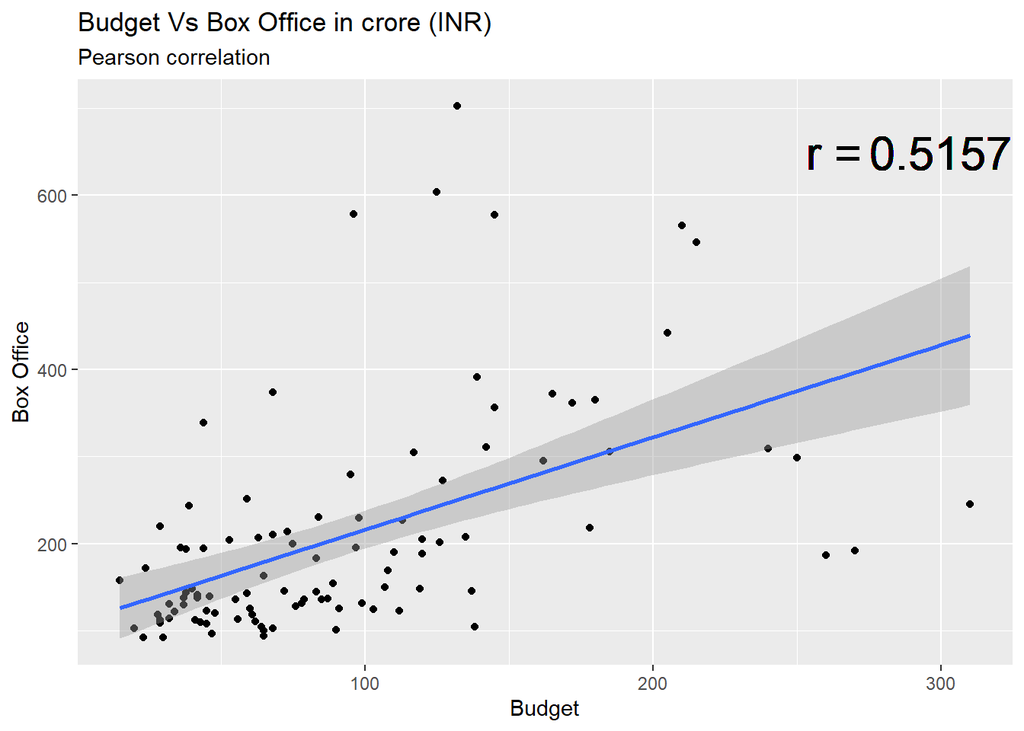

```r
graph_3 <- top_100_box_office %>%
  ggplot(aes(x=Budget_in_crore.INR., y=Worldwide_box_office_gross_in_crore.INR.)) +
  geom_point() +
  geom_smooth(method = lm) +
  labs(x="Budget", y="Box Office", title = "Budget Vs Box Office in crore (INR)", subtitle = "Pearson correlation") +
  geom_text(x=265, y=650, label= "r = ", size = 8) +
  geom_text(x=300, y=650, label= correlation_1, size = 8)

graph_3
```

### According to this test, there is a positive correlation between budget and box office. So if the budget of the movie is high, then there is a chance of a movie to perform well at the box office.

```r
sum(top_100_box_office$Worldwide_box_office_gross_in_crore.INR.)
```

```
## [1] 20892.71
```

### Bollywood top 100 movies earned approximately 20892.71 crores.

### Movies with higher budget are liked by audience or not ?

#### To find this answer I have conducted a pearson correlation test between budget and ratings

```r
ref_2 <- cor.test(top_100_box_office$Budget_in_crore.INR., top_100_box_office$IMDB_Ratings)
correlation_2 <- round(ref_2$estimate, digits = 4)
ref_2
```

```
##
##  Pearson's product-moment correlation
##
## data:  top_100_box_office$Budget_in_crore.INR. and top_100_box_office$IMDB_Ratings
## t = -2.8917, df = 98, p-value = 0.00472
## alternative hypothesis: true correlation is not equal to 0
## 95 percent confidence interval:
##  -0.45191659 -0.08886274
## sample estimates:
##        cor
## -0.2803869
```

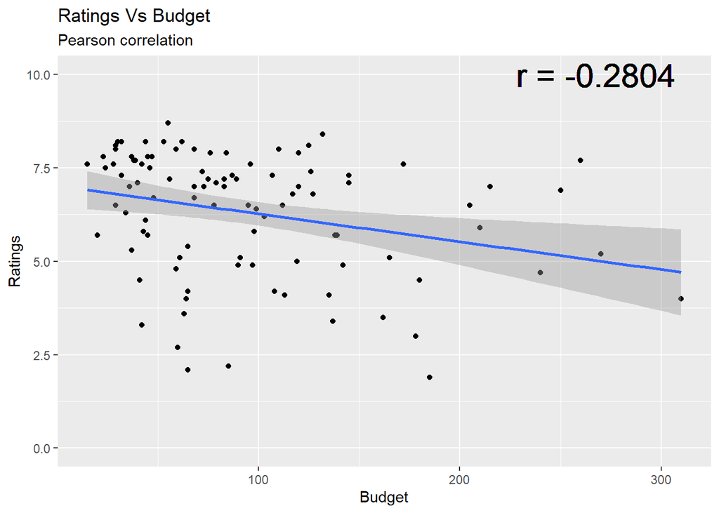

```r
graph_4 <- top_100_box_office %>%
  ggplot(aes(x=Budget_in_crore.INR., y=IMDB_Ratings)) +
  geom_point() +
  geom_smooth(method = lm) +
  ylim(0,10) +
  labs(x="Budget", y="Ratings", title = "Ratings Vs Budget", subtitle = "Pearson correlation") +
  geom_text(x=240, y=10, label= "r = ", size = 8) +
  geom_text(x=280, y=10, label= correlation_2, size = 8)

graph_4
```

### We found out a negetaive correlation

# Final Conclusion

### Movies with higher budgets might perform well at the box office, but in terms of ratings it is not necessary to have a higher budget to win the hearts of the audience. Movies with higher budgets perform well at the box office because of their various promotion techniques but for a movie to be called successful, it should perform well at the box office and also in terms of user ratings.